# _demo_tmp

```python
import pandas as pd


def add_retention(df: pd.DataFrame):
    """
    Calculates the retention rates for different time intervals.

    :param df: Input data
    :return: Data with retention rates
    """
    intervals = [1, 3, 7, 14, 30, 60]
    for interval in intervals:
        dau_col = f"d{interval}_dau"
        ret_col = f"d{interval}_ret"
        df[ret_col] = df[dau_col] / df["installs"]

    return df

def add_arpu(df: pd.DataFrame):
    """
    Calculates the revenue per user different time intervals.

    :param df: Input data
    :return: Data with ARPU
    """
    intervals = [1, 3, 7, 14, 30, 60]
    for interval in intervals:
        revenue_col_iap = f"d{interval}_iap_revenue"
        revenue_col_ads = f"d{interval}_ads_revenue"
        roi_col = f"d{interval}_arpu"
        df[roi_col] = (df[revenue_col_iap] + df[revenue_col_ads]) / df["installs"]
    return df

def add_adsarpu(df: pd.DataFrame):
    """
    Calculates the ads revenue per user different time intervals.

    :param df: Input data
    :return: Data with AdsARPU

    """
    intervals = [1, 3, 7, 14, 30, 60]
    for interval in intervals:
        revenue_col_ads = f"d{interval}_ads_revenue"
        roi_col = f"d{interval}_adsarpu"
        df[roi_col] = (df[revenue_col_ads]) / df["installs"]
    return df

def add_iaparpu(df: pd.DataFrame):
    """
    Calculates the iap revenue per user for different time intervals.

    :param df: Input data
    :return: Data with IAPARPU

    """
    intervals = [1, 3, 7, 14, 30, 60]
    for interval in intervals:
        revenue_col_iap = f"d{interval}_iap_revenue"
        roi_col = f"d{interval}_iaparpu"
        df[roi_col] = (df[revenue_col_iap]) / df["installs"]
    return df


def add_revenue(df: pd.DataFrame):
    """
    Calculates the cumulative revenue for different time intervals.

    :param df: Input data
    :return: Data with Revenue
    """
    intervals = [1, 3, 7, 14, 30, 60]
    for interval in intervals:
        revenue_col_iap = f"d{interval}_iap_revenue"
        revenue_col_ads = f"d{interval}_ads_revenue"
        roi_col = f"d{interval}_revenue"
        df[roi_col] = (df[revenue_col_iap] + df[revenue_col_ads])
    return df

def add_arppu(df: pd.DataFrame):
    """
    Calculates the average revenue per paying users for different time intervals.

    :param df: Input data
    :return: Data with ARPPU
    """
    intervals = [1, 3, 7, 14, 30, 60]
    for interval in intervals:
        revenue_col_iap = f"d{interval}_iap_revenue"
        fts_col = f"d{interval}_first_time_spenders"
        ratio_col = f"d{interval}_arppu"
        df[ratio_col] = df[revenue_col_iap] / df[fts_col]

    return df

def add_fts(df: pd.DataFrame):
    """
    Calculates the ratio of first-time spenders to installs for different time intervals.

    :param df: Input data
    :return: Data with FTS ratio
    """
    intervals = [1, 3, 7, 14, 30, 60]
    for interval in intervals:
        revenue_col_iap = f"d{interval}_iap_revenue"
        fts_col = f"d{interval}_first_time_spenders"
        ratio_col = f"d{interval}_fts_ratio"
        df[ratio_col] = df[fts_col] / df["installs"]

    return df


def add_metrics(df: pd.DataFrame):
    """
    Adds retention, ROI, arpu, adsarpu, iaparpu and FTS ratio metrics to the dataframe.

    :param df: Input data
    :return: Data with retention, ROI, arpu, adsarpu, iaparpu and FTS ratio metrics
    """

    add_retention(df)
    add_arpu(df)
    add_arppu(df)
    add_adsarpu(df)
    add_iaparpu(df)
    add_fts(df)

    return df


# Read the data from the CSV file into a Pandas DataFrame
# This line reads the data from the CSV file into a DataFrame called "data"
data = pd.read_csv("analyst_task1.csv")

# Add performance metrics
data = add_metrics(data)

#Drop the unnecessary columns
data.drop(columns=["d1_dau","d3_dau","d7_dau","d14_dau","d30_dau","d60_dau","d1_iap_revenue",
                    "d3_iap_revenue","d7_iap_revenue","d14_iap_revenue","d30_iap_revenue",
                    "d60_iap_revenue","d1_ads_revenue","d3_ads_revenue","d7_ads_revenue","d14_ads_revenue",
                    "d30_ads_revenue","d60_ads_revenue","d1_first_time_spenders","d3_first_time_spenders",
                    "d7_first_time_spenders","d14_first_time_spenders","d30_first_time_spenders","d60_first_time_spenders"],
           inplace=True)
#Show DataFrame columns
data.columns
```

```
Index(['registration_date', 'game', 'operating_system', 'country', 'installs',
       'd1_ret', 'd3_ret', 'd7_ret', 'd14_ret', 'd30_ret', 'd60_ret',
       'd1_arpu', 'd3_arpu', 'd7_arpu', 'd14_arpu', 'd30_arpu', 'd60_arpu',
       'd1_arppu', 'd3_arppu', 'd7_arppu', 'd14_arppu', 'd30_arppu',
       'd60_arppu', 'd1_adsarpu', 'd3_adsarpu', 'd7_adsarpu', 'd14_adsarpu',
       'd30_adsarpu', 'd60_adsarpu', 'd1_iaparpu', 'd3_iaparpu', 'd7_iaparpu',
       'd14_iaparpu', 'd30_iaparpu', 'd60_iaparpu', 'd1_fts_ratio',
       'd3_fts_ratio', 'd7_fts_ratio', 'd14_fts_ratio', 'd30_fts_ratio',
       'd60_fts_ratio'],
      dtype='object')
```

```python
# Set the display format for floating-point numbers
# This line specifies that floating-point numbers should be displayed with two decimal places
pd.options.display.float_format = '{:,.2f}'.format

# Set the display option to show all columns
# This line sets the display option to show all columns in the DataFrame
pd.set_option('display.max_columns', None)



# Generate descriptive statistics for the data
# This line generates descriptive statistics for the data, such as count, mean, standard deviation, minimum, and maximum values for each column
data.describe()
```

[output not shown]

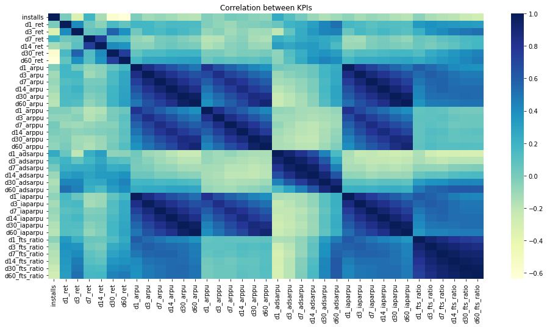

```python
# Import necessary libraries
import seaborn as sns
import matplotlib.pyplot as plt

# Compute the correlation matrix for relevant columns of the data
# This line creates a correlation matrix for the columns of the data that are not registration_date, game, operating_system, or country
corr = data[data.columns[~data.columns.isin(['registration_date','game','operating_system', 'country'])]].corr()

# Create a heatmap to visualize the correlation matrix
# This line creates a heatmap using seaborn to visualize the correlation matrix, with a color map of YlGnBu
plt.figure(figsize=(16,8))
sns.heatmap(corr, cmap="YlGnBu")

# Set the title of the heatmap
# This line sets the title of the heatmap to "Correlation between KPIs"
plt.title('Correlation between KPIs')

# Display the heatmap
# This line displays the heatmap
plt.show()
```

- Positive Correlations: arpu and arppu, iaparpu and arpu, fts ratio and arpu
- Negative Correlations: adsarpu and iaparpu until d30, d1 adsarpu and fts ratio, d1 adsarpu and iaparpu

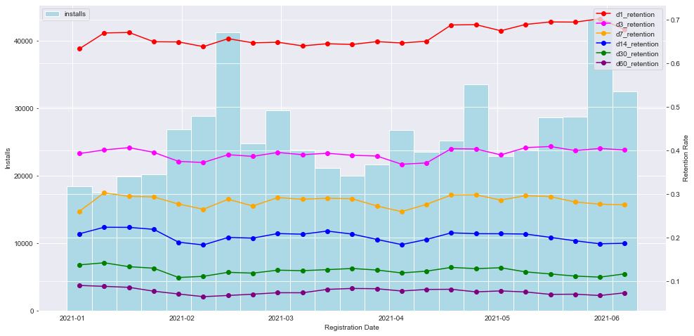

```python
# Convert the date column to a Pandas datetime format
df = data.copy()

df['registration_date'] = pd.to_datetime(df['registration_date'], format='%Y-%m-%d')


# Set the date column as the index
df = df.set_index('registration_date')

# Resample the data to weekly frequency and take the sum of the values for each week
df_weekly = df.resample('W').mean()
#Plotting style
sns.set_style('darkgrid')

# Create the figure and axes object
fig, ax1  =plt.subplots(figsize=(16,8))

ax1.bar(df_weekly.index, df_weekly["installs"], color='lightblue',  width=7, label="installs", )

ax2 = ax1.twinx()
ax2.plot(df_weekly.index, df_weekly['d1_ret'], color='red', marker='o', label="d1_retention")
ax2.plot(df_weekly.index, df_weekly['d3_ret'], color='magenta', marker='o', label="d3_retention")
ax2.plot(df_weekly.index, df_weekly['d7_ret'], color='orange', marker='o', label="d7_retention")
ax2.plot(df_weekly.index, df_weekly['d14_ret'], color='blue', marker='o', label="d14_retention")
ax2.plot(df_weekly.index, df_weekly['d30_ret'], color='green', marker='o', label="d30_retention")
ax2.plot(df_weekly.index, df_weekly['d60_ret'], color='purple', marker='o', label="d60_retention")

ax1.legend(loc="upper left")
ax2.legend(loc="upper right")
ax1.set_ylabel('Installs')
ax2.set_ylabel('Retention Rate')
ax1.set_xlabel('Registration Date')
ax1.grid(linewidth=1)

plt.show()
```

- I turned the data from daily to weekly data therefore the X-Axis represents week date and Y-Axis represents cohorted retention rates.
- As we can see from correlation heatmap Day 1 retention doesn't well correlated any other days retentions
- Also, this line graphic Day 1 Retention doesn't affect any long-term retentions
- Again belong to correlation heatmap, When Day 3 retention decreases the long-term retentions are nearly always effects.
- There is an interesting line in May. In generally, If Day 1 or Day 3 retention increase we can expect those other mid-term and long-term retentions should be increase and it looks like happened in April but it looks like didn't happen in May. I think there is a strategical change here. May be the weight of campaign types can be changed.
- We acquired poor quailty or short term users in last weeks of January until the middle of February. Because as we can see that in this date range our retention rate decreased on mid-term and long-term retentions. The reason of that is may be the UA channels could be changed. We can see the similar situations on where the install peaked like May.
- P.s.
  - Short-Term retentions mean day1, day3
  - Mid-Term retentions mean day7, day14
  - Long-Term retentions mean day30, day60

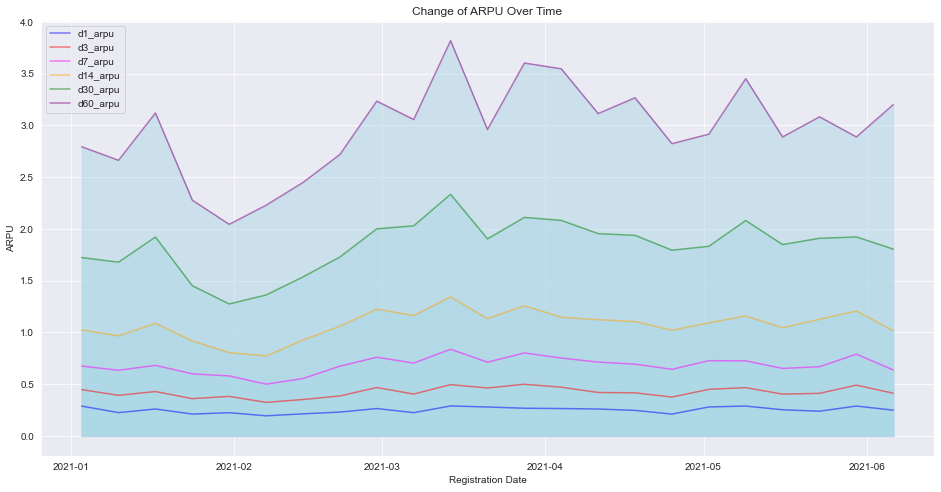

```python
plt.figure(figsize=(16,8))
# Create the area chart
sns.lineplot(x=df_weekly.index, y=df_weekly["d1_arpu"], color='blue', label='d1_arpu', alpha=0.5)
sns.lineplot(x=df_weekly.index, y=df_weekly["d3_arpu"], color='red', label='d3_arpu', alpha=0.5)
sns.lineplot(x=df_weekly.index, y=df_weekly["d7_arpu"], color='magenta', label='d7_arpu', alpha=0.5)
sns.lineplot(x=df_weekly.index, y=df_weekly["d14_arpu"], color='orange', label='d14_arpu', alpha=0.5)
sns.lineplot(x=df_weekly.index, y=df_weekly["d30_arpu"], color='green', label='d30_arpu', alpha=0.5)
sns.lineplot(x=df_weekly.index, y=df_weekly["d60_arpu"], color='purple', label='d60_arpu', alpha=0.5)

plt.fill_between(df_weekly.index, df_weekly["d1_arpu"], alpha=0.5, color='lightblue')
plt.fill_between(df_weekly.index, df_weekly["d3_arpu"], alpha=0.5, color='lightblue')
plt.fill_between(df_weekly.index, df_weekly["d7_arpu"], alpha=0.5, color='lightblue')
plt.fill_between(df_weekly.index, df_weekly["d14_arpu"], alpha=0.5, color='lightblue')
plt.fill_between(df_weekly.index, df_weekly["d30_arpu"], alpha=0.5, color='lightblue')
plt.fill_between(df_weekly.index, df_weekly["d60_arpu"], alpha=0.5, color='lightblue')
# Set chart labels and title
sns.set_style('darkgrid')
plt.title("Change of ARPU Over Time")
plt.xlabel("Registration Date")
plt.ylabel("ARPU")
plt.legend()
plt.show()
```

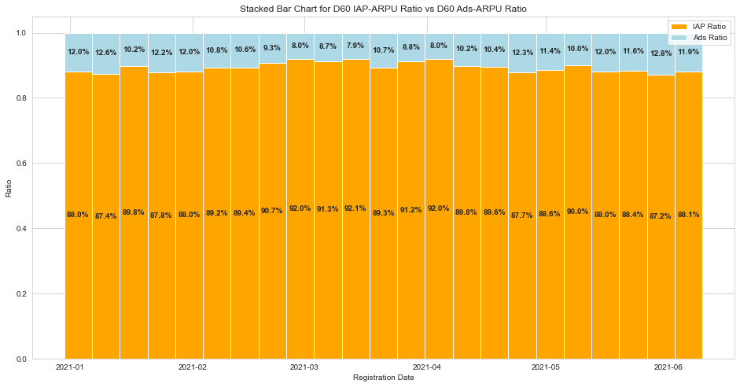

```python
plt.figure(figsize=(16,8))
sns.set_style('whitegrid')
plt.bar(df_weekly.index, df_weekly["d60_iaparpu"]/df_weekly["d60_arpu"], color='orange',  width=7, label='IAP Ratio')
plt.bar(df_weekly.index, df_weekly["d60_adsarpu"]/df_weekly["d60_arpu"], bottom=df_weekly["d60_iaparpu"]/df_weekly["d60_arpu"], color='lightblue',  width=7,  label='Ads Ratio')

# add labels to the bars
iap_labels = df_weekly["d60_iaparpu"]/df_weekly["d60_arpu"]
ads_labels = df_weekly["d60_adsarpu"]/df_weekly["d60_arpu"]
for i in range(len(df_weekly)):
    plt.text(df_weekly.index[i], iap_labels[i]/2, f"{iap_labels[i]*100:.1f}%", ha='center', va='center', fontweight='bold')
    plt.text(df_weekly.index[i], iap_labels[i]+ads_labels[i]/2, f"{ads_labels[i]*100:.1f}%", ha='center', va='center', fontweight='bold')

# add chart labels and legend
plt.xlabel('Registration Date')
plt.ylabel('Ratio')
plt.title('Stacked Bar Chart for D60 IAP-ARPU Ratio vs D60 Ads-ARPU Ratio')
plt.legend()

# show the chart
plt.show()
```

- The graphic represents basically main monetization resource of the game is inapp purchase.
- Also,We saw on previous 2 graphs that there is a decreasing in D60 ARPU in last weeks of January until the Middle of February. Now, we can assume clearly if there is a strategical choice for January and February months and even acquired short-term or poor quality users the balance of revenue ratio doesn't change.
- One of the reasons of that is the game has good quality of game design and game economy.